# dsti_a21_R

###2.3 Entire home or apartment,Private Room, Shared Room

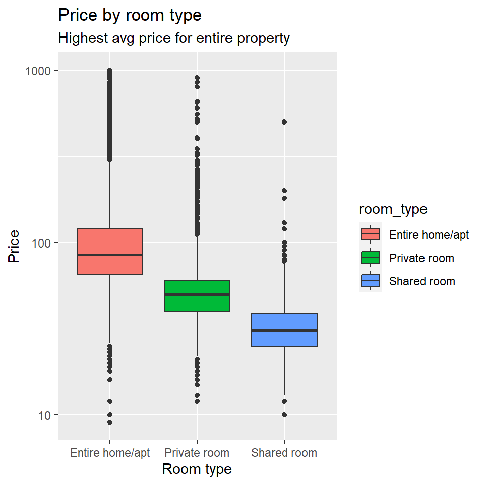

###2.4 Number of appartement per owners

- We create a subset with the number of apartments per distinct owner

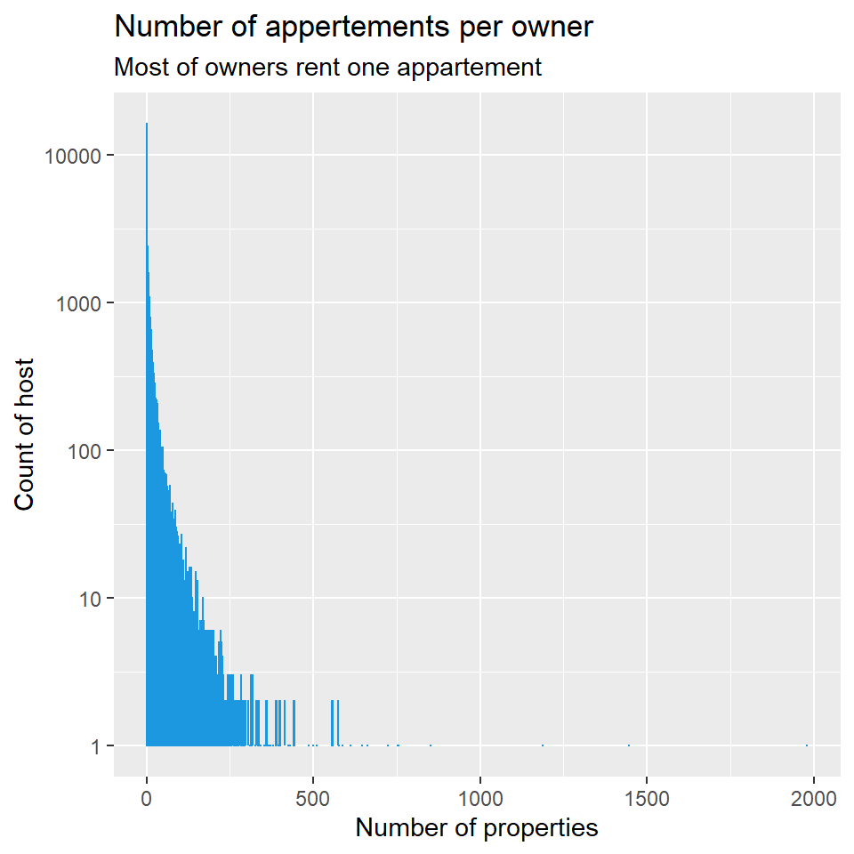

###2.5 Owners list with more than 50 apartments

- We create a column with the ID number and the nickname of the owner

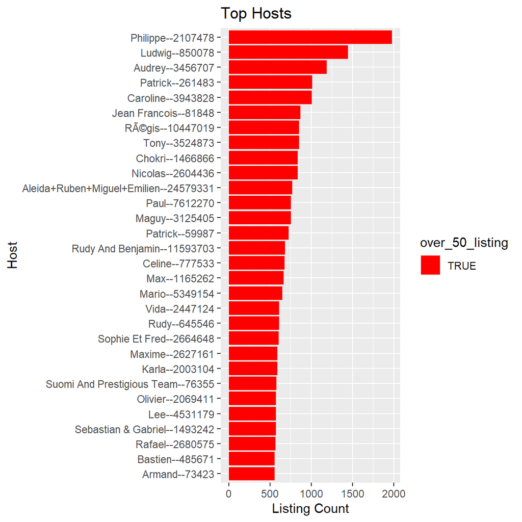

###2.6 Renting price per city quarter (arrondissements)

- Don’t forget to include 75116 since 75116 represents 16th North and 75016 represents 16th South
- The 18th and 11th are the arrondissements where there are the most ads

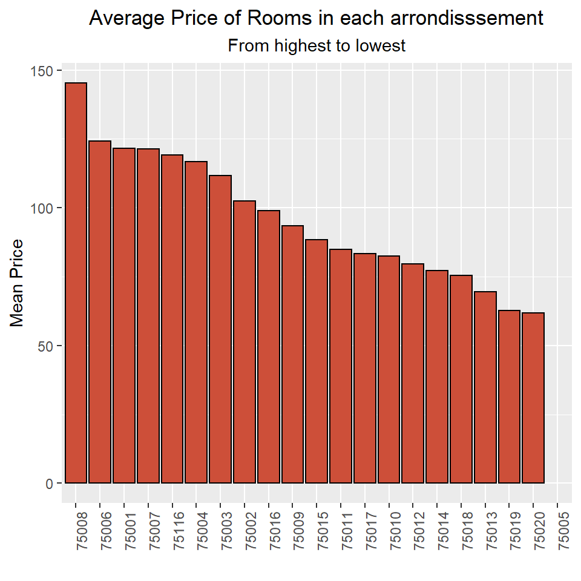

###2.7 Evolution of the number of reviews according to the years

- There is more and more activity. The year 2016 is underway

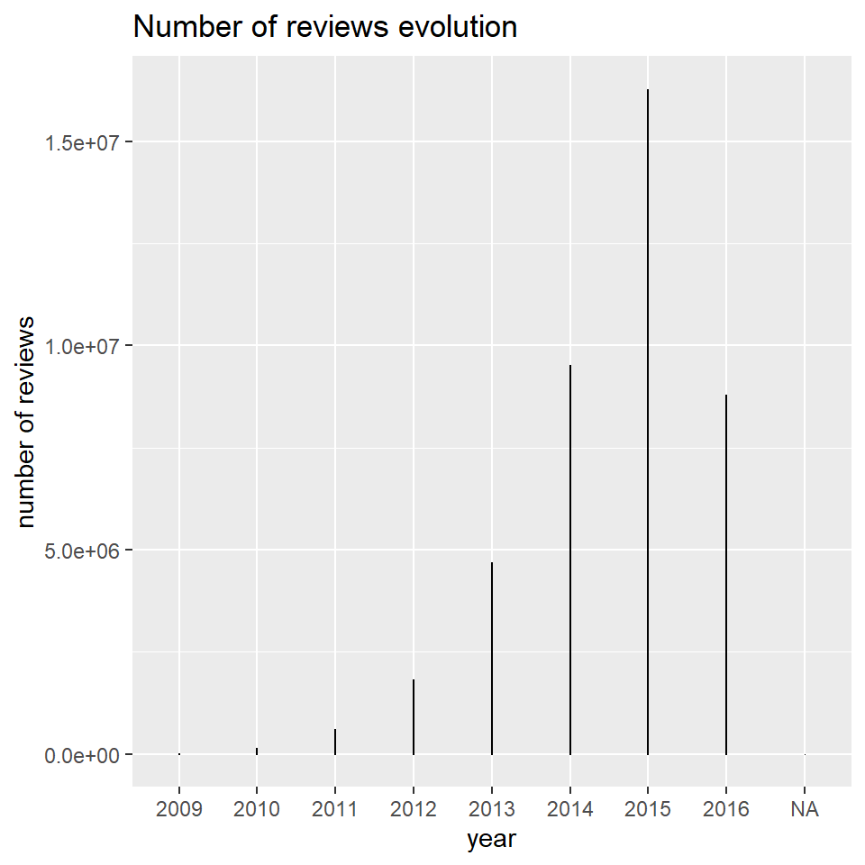